# PA1_template

*Marc Durbin*  
*November 15, 2015*

Prepare R for knitr

```r
library(knitr)
opts_chunk$set(echo = TRUE, results = 'hold')
```

Read in the dataset and process the data:

```r
if(!file.exists("./data")){dir.create("./data")}

# download compressed file and decompress it
fileUrl <- "https://d396qusza40orc.cloudfront.net/repdata%2Fdata%2Factivity.zip"
download.file(fileUrl, destfile = "./data/activity.zip", method = "curl")
unzip(zipfile="./data/activity.zip", exdir = "./data")

# get file type
list.files("./data")

# read csv file into R and create dataframe
data <- read.csv("./data/activity.csv")

# convert classes
data$date <- as.Date(data$date, format = "%Y-%m-%d")
data$interval <- as.factor(data$interval)

# inspect raw data
summary(data)
```

```
## [1] "activity.csv" "activity.zip"
##      steps             date               interval
##  Min.   :  0.00   Min.   :2012-10-01   0      :   61
##  1st Qu.:  0.00   1st Qu.:2012-10-16   5      :   61
##  Median :  0.00   Median :2012-10-31   10     :   61
##  Mean   : 37.38   Mean   :2012-10-31   15     :   61
##  3rd Qu.: 12.00   3rd Qu.:2012-11-15   20     :   61
##  Max.   :806.00   Max.   :2012-11-30   25     :   61
##  NA's   :2304                          (Other):17202
```

Create a histogram of the total number of steps taken each day:

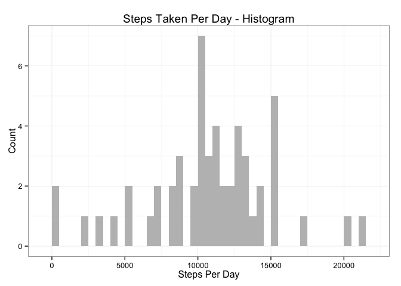

```r
library(ggplot2)

steps_per_day <- aggregate(steps ~ date, data, sum)
colnames(steps_per_day) <- c("date","steps")

ggplot(steps_per_day, aes(x = steps)) +
        geom_histogram(fill = "gray", binwidth = 500) +
        labs(title="Steps Taken Per Day - Histogram",
             x = "Steps Per Day", y = "Count") + theme_bw()
```

Mean number of steps taken each day is 10766.19

```r
steps_mean   <- mean(steps_per_day$steps, na.rm=TRUE)
steps_mean
```

```
## [1] 10766.19
```

Median number of steps taken each day is 10765

```r
steps_median <- median(steps_per_day$steps, na.rm=TRUE)
steps_median
```

```
## [1] 10765
```

Time series plot of the average number of steps taken (averaged across all days) versus the 5-minute intervals:

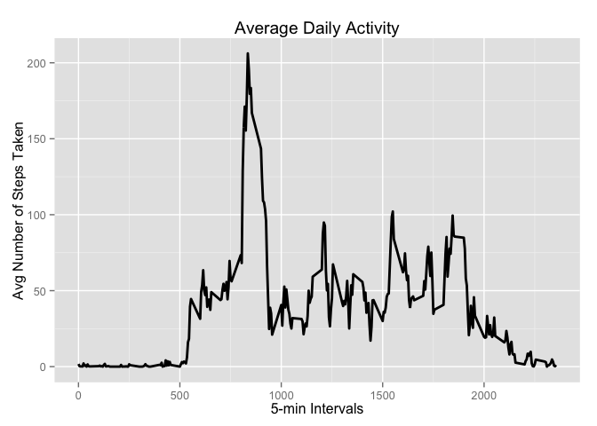

```r
steps5int <- aggregate(data$steps, by = list(interval = data$interval), FUN=mean, na.rm=TRUE)

steps5int$interval <- as.integer(levels(steps5int$interval)[steps5int$interval])
colnames(steps5int) <- c("interval", "steps")

ggplot(steps5int, aes(x=interval, y=steps)) +
        geom_line(color="black", size=1) +
        labs(title="Average Daily Activity", x="5-min Intervals", y="Avg Number of Steps Taken")
```

```r
max_steps <- steps5int[which.max(steps5int$steps),]
max_steps$interval
```

```
## [1] 835
```

```r
max_steps$steps
```

```
## [1] 206.1698
```

### Strategy for imputing missing data

Number of NAs is 2304

```r
summary(data)
```

```
##      steps             date               interval
##  Min.   :  0.00   Min.   :2012-10-01   0      :   61
##  1st Qu.:  0.00   1st Qu.:2012-10-16   5      :   61
##  Median :  0.00   Median :2012-10-31   10     :   61
##  Mean   : 37.38   Mean   :2012-10-31   15     :   61
##  3rd Qu.: 12.00   3rd Qu.:2012-11-15   20     :   61
##  Max.   :806.00   Max.   :2012-11-30   25     :   61
##  NA's   :2304                          (Other):17202
```

Our strategy for imputing missing data will be to use the mean value and replace all NAs.

```r
na_fill <- function(data, pervalue) {
        na_index <- which(is.na(data$steps))
        na_replace <- unlist(lapply(na_index, FUN=function(idx){
                interval = data[idx,]$interval
                pervalue[pervalue$interval == interval,]$steps
        }))
        fill_steps <- data$steps
        fill_steps[na_index] <- na_replace
        fill_steps
}

data_fill <- data.frame(
        steps = na_fill(data, steps5int),
        date = data$date,
        interval = data$interval)
```

Check first 10 observations in “steps” column, before and after:

```r
data[1:10,1]
data_fill[1:10,1]
```

```
##  [1] NA NA NA NA NA NA NA NA NA NA
##  [1] 1.7169811 0.3396226 0.1320755 0.1509434 0.0754717 2.0943396 0.5283019
##  [8] 0.8679245 0.0000000 1.4716981
```

Confirm non-existence of NAs:

```r
sum(is.na(data_fill$steps))
```

```
## [1] 0
```

Histogram of the total number of steps taken each day after missing values have been imputed.

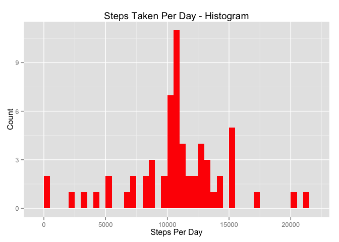

```r
fill_steps_per_day <- aggregate(steps ~ date, data_fill, sum)
colnames(fill_steps_per_day) <- c("date","steps")

ggplot(fill_steps_per_day, aes(x = steps)) +
        geom_histogram(fill = "red", binwidth = 500) +
        labs(title="Steps Taken Per Day - Histogram",
             x = "Steps Per Day", y = "Count")
```

```r
steps_mean_fill   <- mean(fill_steps_per_day$steps, na.rm=TRUE)
steps_median_fill <- median(fill_steps_per_day$steps, na.rm=TRUE)
```

Code below is for comparing the average number of steps taken per 5-minute interval across weekdays and weekends

```r
weekdays_steps <- function(data) {
        weekdays_steps <- aggregate(data$steps, by=list(interval = data$interval), FUN=mean, na.rm=T)
        weekdays_steps$interval <- as.integer(levels(weekdays_steps$interval)[weekdays_steps$interval])
        colnames(weekdays_steps) <- c("interval", "steps")
        weekdays_steps
        }

data_by_weekdays <- function(data) {
        data$weekday <- as.factor(weekdays(data$date))
        weekend_data <- subset(data, weekday %in% c("Saturday","Sunday"))
        weekday_data <- subset(data, !weekday %in% c("Saturday","Sunday"))

        weekend_steps <- weekdays_steps(weekend_data)
        weekday_steps <- weekdays_steps(weekday_data)

        weekend_steps$dayofweek <- rep("weekend", nrow(weekend_steps))
        weekday_steps$dayofweek <- rep("weekday", nrow(weekday_steps))

        data_by_weekdays <- rbind(weekend_steps, weekday_steps)
        data_by_weekdays$dayofweek <- as.factor(data_by_weekdays$dayofweek)
        data_by_weekdays
        }

data_weekdays <- data_by_weekdays(data_fill)

head(data_weekdays)
```

```
##   interval       steps dayofweek
## 1        0 0.214622642   weekend
## 2        5 0.042452830   weekend
## 3       10 0.016509434   weekend
## 4       15 0.018867925   weekend
## 5       20 0.009433962   weekend
## 6       25 3.511792453   weekend
```

### Panel Plot

for comparing the average number of steps taken per 5-minute interval across weekdays and weekends

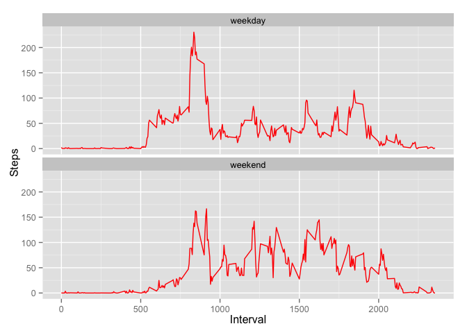

```r
ggplot(data_weekdays, aes(x=interval, y=steps)) + geom_line(color="red") +
        facet_wrap(~ dayofweek, nrow=2, ncol=1) + labs(x="Interval", y="Steps")
```